# Modern concepts and methods in Macroecology and Biogeography

Day 3: Download point occurrences & fit species distribution models

Patrick Weigelt, Pierre Denelle, & Holger Kreft

April 24th, 2024

*back to overview*

**Preparation:** Please open your RStudio project and download all new data for the class from [Stud-IP](https://studip.uni-goettingen.de/dispatch.php/course/files/index/74501b33f332a6d238443bfbd502cc6c?cid=1746ae3fe971afbf90b74e3d64389586) (log in first) and unzip them into your project folder /data/. You can use `getwd()` to get your current working directory which is your project folder as long as you do not change it. Please install the following R-packages using `install.packages()` if not done yet:

- sf
- terra
- dplyr
- BIEN
- ROCR
- performance

If you want to visualize this tutorial in the viewer inside RStudio (to save space on your screen) run the following chunk of code:

```r
install.packages("rstudioapi") # install an R-package required for this step
dir <- tempfile()
dir.create(dir)
download.file("https://gift.uni-goettingen.de/mcmmb/index.html",
              destfile = file.path(dir, "index.html"))
download.file("https://gift.uni-goettingen.de/mcmmb/Day3.html",
              destfile = file.path(dir, "Day3.html"))
htmlFile <- file.path(dir, "Day3.html")
rstudioapi::viewer(htmlFile)
```

Now you can conveniently copy code from the viewer into your script.

# 1. Loading palm data set and setting up for later analyses

**Clean up workspace**

```r
rm(list=ls()) # remove all objects first; alternatively press CTRL+SHIFT+F10 to also unmap loaded packages
```

**Load R packages & palm data set**

```r
library(dplyr)
library(sf)
library(terra)
library(BIEN)
library(ROCR)
library(performance)
```

For today’s exercise, we will continue to use the Neotropical palm data set from [Kreft, H., Sommer, J.H. & Barthlott, W. (2006) The significance of geographic range size for spatial diversity patterns in Neotropical palms. *Ecography*, 29, 21-30](https://onlinelibrary.wiley.com/doi/full/10.1111/j.2005.0906-7590.04203.x).

```r
species <- read.csv("data/palms_species_per_gridcell.csv")
```

**Data inspection**

```r
head(species)
```

```
##   grid_id spp_Id    GENUS EPITHET
## 1   13735    550 Ammandra natalia
## 2   13736    550 Ammandra natalia
## 3   13737    550 Ammandra natalia
## 4   13738    550 Ammandra natalia
## 5   13910    550 Ammandra natalia
## 6   13911    550 Ammandra natalia
```

```r
str(species)
```

```
## 'data.frame':    140860 obs. of  4 variables:
##  $ grid_id: int  13735 13736 13737 13738 13910 13911 13912 13913 13914 14085 ...
##  $ spp_Id : int  550 550 550 550 550 550 550 550 550 550 ...
##  $ GENUS  : chr  "Ammandra" "Ammandra" "Ammandra" "Ammandra" ...
##  $ EPITHET: chr  "natalia" "natalia" "natalia" "natalia" ...
```

```r
species$species <- paste(species$GENUS,species$EPITHET, sep = " ") # make new column combining 'Genus' and 'Epithet'
```

**Create a subset of the palm data set (4 palm species)**

```r
species <- species[which(species$species %in%
                           c("Geonoma pauciflora","Geonoma weberbaueri",
                             "Phytelephas tenuicaulis","Mauritia flexuosa")),]
unique(species$species) # list species in data set
```

```
## [1] "Phytelephas tenuicaulis" "Geonoma weberbaueri"
## [3] "Geonoma pauciflora"      "Mauritia flexuosa"
```

```r
species$species[which(species$species == "Geonoma weberbaueri")] <- "Geonoma undata" # Rename to accepted name in World Checklist of Vascular Plants
```

**Load GIS shapefile & join it to species distribution data**

```r
# read a polygon shapefile
grid <- st_read("data/30min_grid_select50/30min_grid_select50%.shp")
```

```r
st_crs(grid) <- "+proj=longlat +ellps=WGS84 +no_defs" # remember to include coordinate system
#plot(st_geometry(grid))

# convert long table to a wide table
species <- species[, c("grid_id","species")]

species_grid <- as.data.frame.matrix(table(species))
species_grid <- data.frame(grid_id = as.integer(row.names(species_grid)), species_grid)

names(grid)[1] <- "grid_id"

grid <- left_join(grid, species_grid, by = "grid_id")

grid[is.na(grid)] <- 0 # convert NAs to zeroes
grid[1:5,1:5] # inspect data frame
```

```
## Simple feature collection with 5 features and 5 fields
## Geometry type: MULTIPOLYGON
## Dimension:     XY
## Bounding box:  xmin: -115.0007 ymin: 35.5 xmax: -113.0007 ymax: 36.5
## Geodetic CRS:  +proj=longlat +ellps=WGS84 +no_defs
##   grid_id AREA PORTION Geonoma.pauciflora Geonoma.undata
## 1     538 0.25     100                  0              0
## 2     539 0.25     100                  0              0
## 3     540 0.25     100                  0              0
## 4     712 0.25     100                  0              0
## 5     713 0.25     100                  0              0
##                         geometry
## 1 MULTIPOLYGON (((-114.0007 3...
## 2 MULTIPOLYGON (((-113.5007 3...
## 3 MULTIPOLYGON (((-113.0007 3...
## 4 MULTIPOLYGON (((-114.5007 3...
## 5 MULTIPOLYGON (((-114.0007 3...
```

Other options to convert ‘long’ data frames to ‘wide’ ones include ‘dcast’ via the *reshape2* package or ‘pivot_wider’ via the *tidyr* package.

# 2. Download point occurrences (presences)

For today’s practical, we will use occurrence data downloaded from [BIEN](http://bien.nceas.ucsb.edu/bien/tools/). This file is also available via StudIP (’Data/Data/BIEN_data.csv).

```r
#spec_occ <- BIEN_occurrence_species(c("Geonoma pauciflora","Geonoma undata","Phytelephas tenuicaulis","Mauritia flexuosa"), cultivated = FALSE, new.world = TRUE) # Download via the internet (this can take quite some time!)

spec_occ <- read.csv("data/BIEN_data.csv") # Or load species occurrence data from disk

head(spec_occ)
```

```
##   scrubbed_species_binomial  latitude longitude date_collected  datasource
## 1        Geonoma pauciflora -24.25000 -46.93300     1987-09-03          NY
## 2        Geonoma pauciflora -24.04778 -46.81833     2001-04-16 SpeciesLink
## 3        Geonoma pauciflora -14.33333 -39.16667     1994-02-13        GBIF
## 4        Geonoma pauciflora -24.04122 -46.82442     2001-04-17        GBIF
## 5        Geonoma pauciflora -13.59528 -39.72167     2001-07-26        GBIF
## 6        Geonoma pauciflora -12.86972 -39.47694           <NA>        GBIF
##                                                 dataset
## 1                                                    NY
## 2                                               UNICAMP
## 3                                                   USP
## 4 Escola Superior de Agricultura Luiz de Queiroz, ESALQ
## 5                                                  UESC
## 6                                              Cenargen
##                                               dataowner
```

[output cut: 20 more lines]

```r
dim(spec_occ) # how many observations?
```

```
## [1] 1408   10
```

**Exercise**

1. Subset data set (spec_occ) to only include records with spatial coordinates
2. Count how many records there are for each species

**Exercise solution**

```
##   scrubbed_species_binomial  latitude longitude date_collected  datasource
## 1        Geonoma pauciflora -24.25000 -46.93300     1987-09-03          NY
## 2        Geonoma pauciflora -24.04778 -46.81833     2001-04-16 SpeciesLink
## 3        Geonoma pauciflora -14.33333 -39.16667     1994-02-13        GBIF
## 4        Geonoma pauciflora -24.04122 -46.82442     2001-04-17        GBIF
## 5        Geonoma pauciflora -13.59528 -39.72167     2001-07-26        GBIF
## 6        Geonoma pauciflora -12.86972 -39.47694           <NA>        GBIF
##                                                 dataset
## 1                                                    NY
## 2                                               UNICAMP
## 3                                                   USP
## 4 Escola Superior de Agricultura Luiz de Queiroz, ESALQ
## 5                                                  UESC
## 6                                              Cenargen
##                                               dataowner
```

[output cut: 20 more lines]

```
##
##      Geonoma pauciflora          Geonoma undata       Mauritia flexuosa
##                     133                     814                     420
## Phytelephas tenuicaulis
##                      41
```

**Map occurrence records and species ranges**  
Here we use colorblind friendly colors, which can be found via [Colorbrewer2](http://colorbrewer2.org).

```r
# Shape file showing the borders of the Neotropics
americas <- st_read("data/americas/americas.shp")
st_crs(americas) <- "+proj=longlat +ellps=WGS84 +no_defs"
```

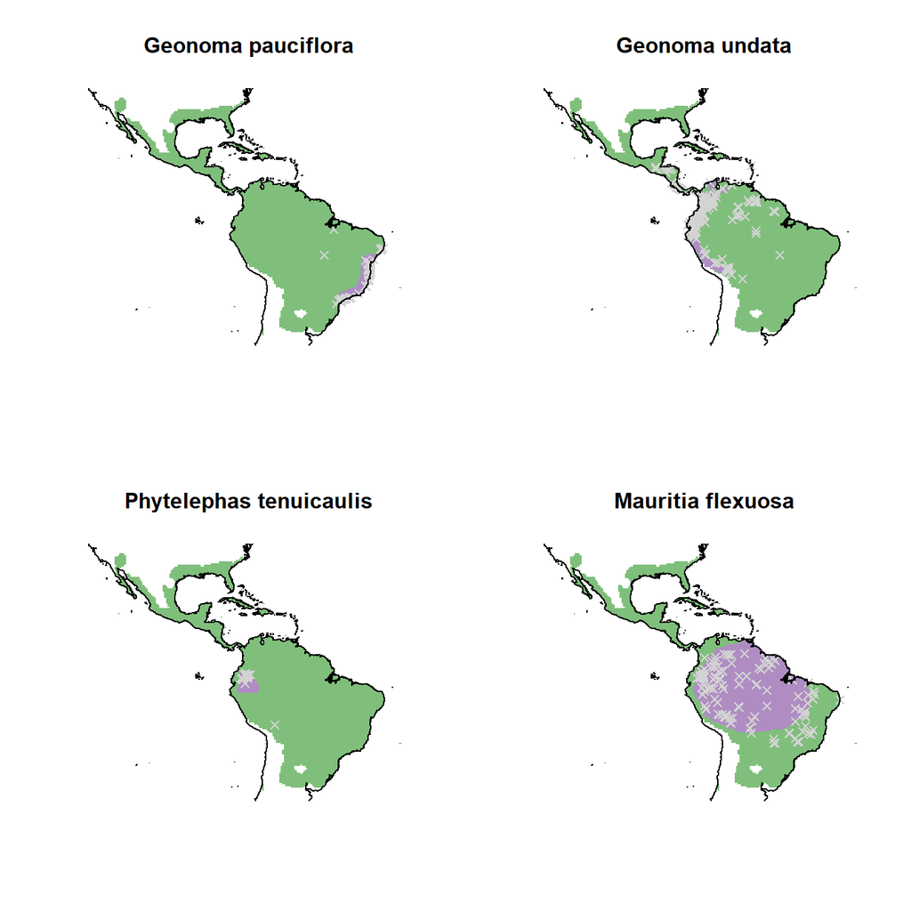

```r
par(mfrow = c(2, 2))
plot(st_geometry(grid),
     col = ifelse(grid$Geonoma.pauciflora == 1, "#af8dc3", "#7fbf7b"),
     border = FALSE, main = "Geonoma pauciflora")
#species 1
points(spec_occ$longitude[which(spec_occ$scrubbed_species_binomial == "Geonoma pauciflora")],
       spec_occ$latitude[which(spec_occ$scrubbed_species_binomial == "Geonoma pauciflora")],
       col = "lightgrey", pch = 4)
plot(st_geometry(americas), add = TRUE)

#species 2
plot(st_geometry(grid),
     col=ifelse(grid$Geonoma.undata==1,"#af8dc3", "#7fbf7b"),
     border=FALSE, main = "Geonoma undata")
points(spec_occ$longitude[which(spec_occ$scrubbed_species_binomial == "Geonoma undata")],
       spec_occ$latitude[which(spec_occ$scrubbed_species_binomial == "Geonoma undata")],
       col = "lightgrey", pch = 4)
plot(st_geometry(americas), add = TRUE)

#species 3
plot(st_geometry(grid),
     col=ifelse(grid$Phytelephas.tenuicaulis==1,"#af8dc3","#7fbf7b"),
     border=FALSE, main = "Phytelephas tenuicaulis")
points(spec_occ$longitude[which(spec_occ$scrubbed_species_binomial == "Phytelephas tenuicaulis")],
       spec_occ$latitude[which(spec_occ$scrubbed_species_binomial == "Phytelephas tenuicaulis")],
       col="lightgrey", pch=4)
plot(st_geometry(americas), add = TRUE)

#species 4
plot(st_geometry(grid),
     col=ifelse(grid$Mauritia.flexuosa==1,"#af8dc3","#7fbf7b"),
     border=FALSE, main = "Mauritia flexuosa")
points(spec_occ$longitude[which(spec_occ$scrubbed_species_binomial == "Mauritia flexuosa")],
       spec_occ$latitude[which(spec_occ$scrubbed_species_binomial == "Mauritia flexuosa")],
       col="lightgrey", pch=4)
plot(st_geometry(americas), add = TRUE)
```

# 3. Create pseudo‐absences (background data)

Pseudo-absences are necessary because occurrence data sets (like BIEN) only record presences and not true absences. Therefore, we must generate pseudo-absences, i.e. possible locations where a species doesn’t occur.

**Make spatial points data frame from grid**

```r
grid_centroids <- st_centroid(grid)
```

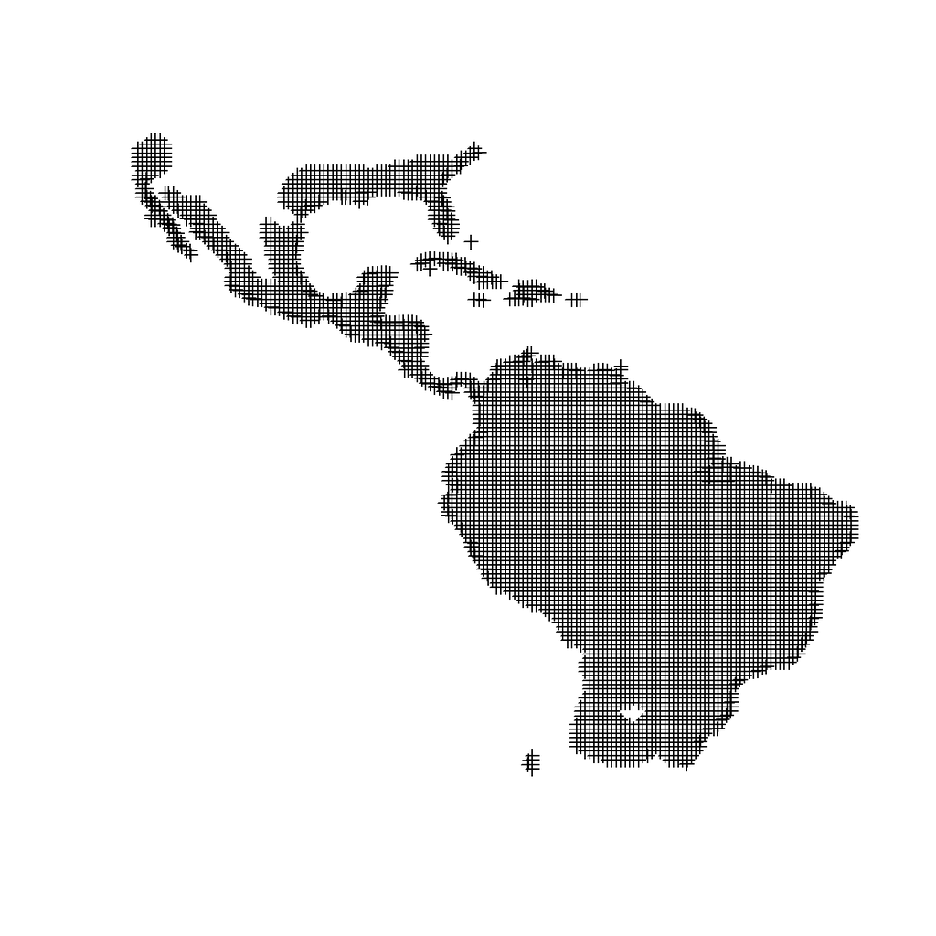

```r
grid_centroids$present <- 0

par(mfrow = c(1, 1))
plot(st_geometry(grid_centroids), pch = 3)
```

**Make spatialPoint objects for occurrences of each species**

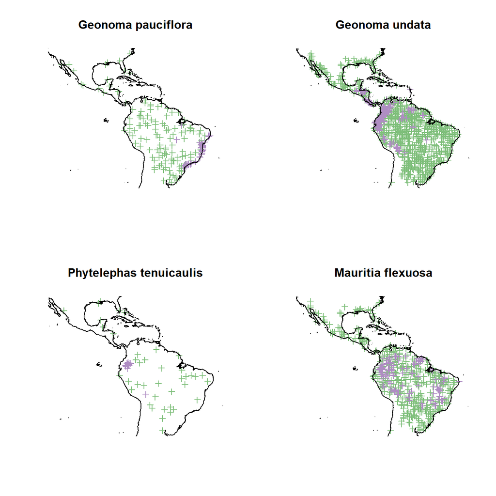

```r
# Geonoma pauciflora
geo_pau <- st_as_sf(
  spec_occ[which(spec_occ$scrubbed_species_binomial == "Geonoma pauciflora"),
           c("longitude", "latitude")],
  coords = c("longitude", "latitude"),
  crs = "+proj=longlat +ellps=WGS84 +no_defs")
geo_pau$present <- 1

# add pseudo-absences
set.seed(100)
geo_pau_abs <- rbind(grid_centroids[sample(nrow(grid_centroids),
                                           nrow(geo_pau), replace = TRUE),
                                    "present"],
                     geo_pau)

par(mfrow = c(2, 2))

plot(st_geometry(geo_pau_abs),
     col = ifelse(geo_pau_abs$present == 1, "#af8dc3", "#7fbf7b"),
     main = "Geonoma pauciflora", pch = 3)
plot(st_geometry(americas), add = TRUE)

# Geonoma undata
geo_und <- st_as_sf(
  spec_occ[which(spec_occ$scrubbed_species_binomial == "Geonoma undata"),
           c("longitude", "latitude")],
  coords = c("longitude", "latitude"),
  crs = "+proj=longlat +ellps=WGS84 +no_defs")
geo_und$present <- 1

# add pseudo-absences
set.seed(100)
geo_und_abs <- rbind(
  grid_centroids[sample(nrow(grid_centroids),
                        nrow(geo_und), replace = TRUE), "present"],
  geo_und)

plot(st_geometry(geo_und_abs),
     col=ifelse(geo_und_abs$present == 1,"#af8dc3", "#7fbf7b"),
     main="Geonoma undata", pch = 3)
plot(st_geometry(americas), add = TRUE)

# Phytelephas tenuicaulis
phy_ten <- st_as_sf(
  spec_occ[which(spec_occ$scrubbed_species_binomial == "Phytelephas tenuicaulis"),
           c("longitude","latitude")],
  coords = c("longitude", "latitude"),
  crs = "+proj=longlat +ellps=WGS84 +no_defs")
phy_ten$present <- 1

# add pseudo-absences
set.seed(100)
phy_ten_abs <- rbind(
  grid_centroids[sample(nrow(grid_centroids),
                        nrow(phy_ten), replace = TRUE), "present"],
  phy_ten)

plot(st_geometry(phy_ten_abs),
     col=ifelse(phy_ten_abs$present==1, "#af8dc3", "#7fbf7b"),
     main="Phytelephas tenuicaulis", pch = 3)
plot(st_geometry(americas), add = TRUE)

# Mauritia flexuosa
mau_fle <- st_as_sf(
  spec_occ[which(spec_occ$scrubbed_species_binomial == "Mauritia flexuosa"),
           c("longitude", "latitude")],
  coords = c("longitude", "latitude"),
  crs = "+proj=longlat +ellps=WGS84 +no_defs")
mau_fle$present <- 1

# add pseudo-absences
set.seed(100)
mau_fle_abs <- rbind(
  grid_centroids[sample(nrow(grid_centroids),
                        nrow(mau_fle), replace = TRUE), "present"],
  mau_fle)

plot(st_geometry(mau_fle_abs),
     col = ifelse(mau_fle_abs$present == 1,"#af8dc3", "#7fbf7b"),
     main="Mauritia flexuosa", pch = 3)
plot(st_geometry(americas), add = TRUE)
```

# 4. Load and extract environmental data

**Load environmental data**  
For today’s exercise, we use: elevation, temperature (‘bio1’), and precipitation (‘bio12’).  
Please note that temperature has been multiplied by 10.

```r
# Import global digital elevation model at 30 arc seconds resolution
elev <- rast("data/mn30_grd/") + 0 # +0 to treat raster as numeric
```

```
##
|---------|---------|---------|---------|
=========================================
```

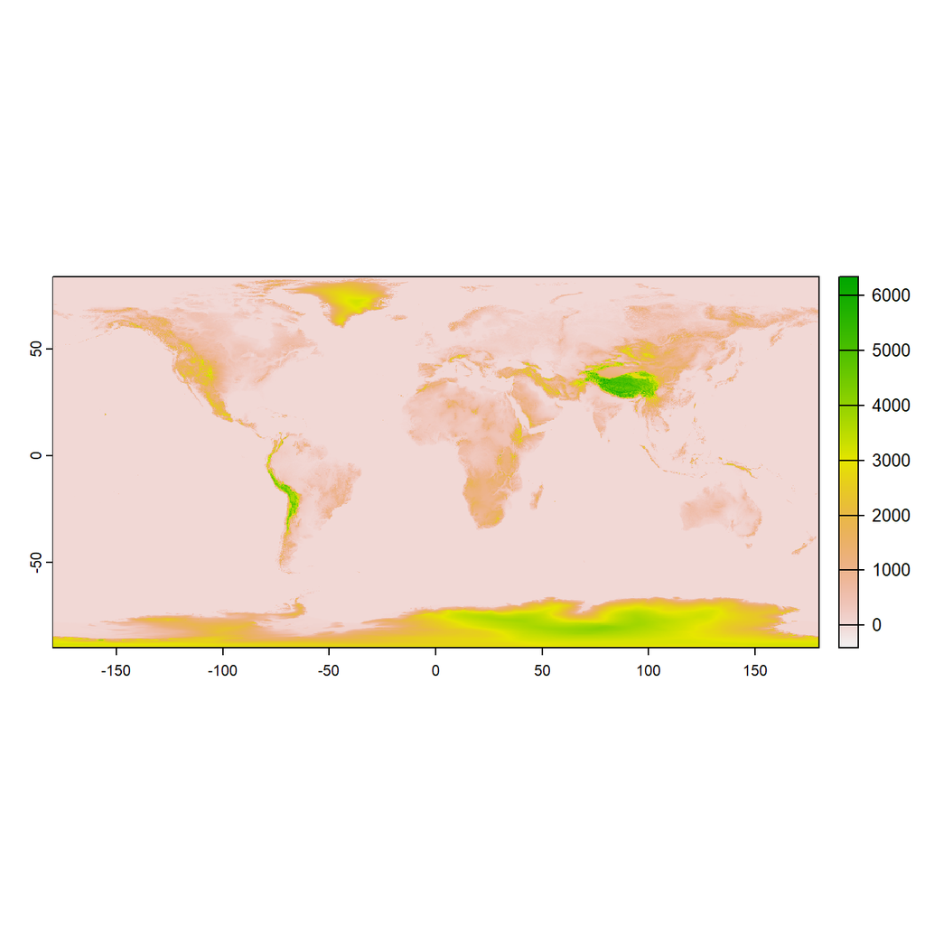

```r
plot(elev)

par(mfrow=c(1,1))
plot(elev)
```

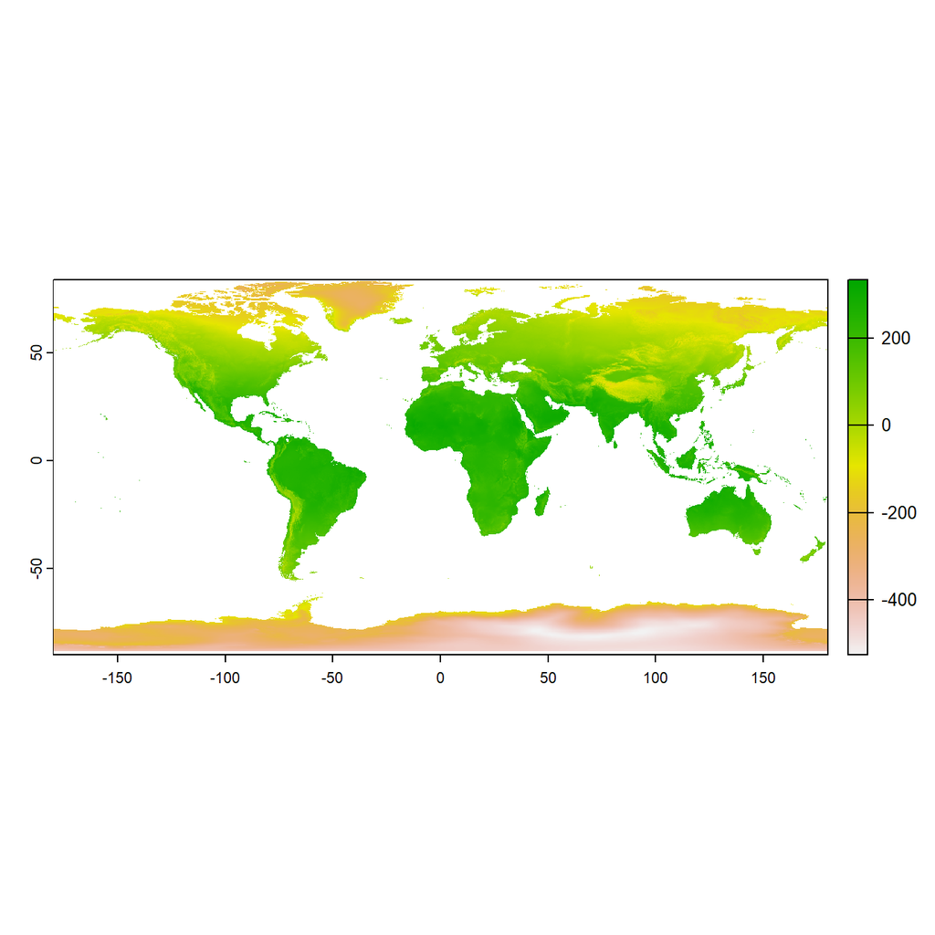

```r
# Import climate data from Chelsa at 30 arc seconds resolution -->
bio1 <- rast("data/CHELSA_bio10_01.tif") # temperature*10
bio12 <- rast("data/CHELSA_bio10_12.tif") # precipitation
plot(bio1)
```

**Extract environmental data for each point (presences/absences)**

```r
# extract environmental data for presences and absences
geo_pau_abs$elev <- extract(elev, geo_pau_abs)[, "mn30_grd"]
geo_pau_abs$bio1 <- extract(bio1,geo_pau_abs)[, "CHELSA_bio10_01"]
geo_pau_abs$bio12 <- extract(bio12,geo_pau_abs)[, "CHELSA_bio10_12"]
geo_pau_abs <- na.omit(geo_pau_abs)

geo_und_abs$elev <- extract(elev,geo_und_abs)[, "mn30_grd"]
geo_und_abs$bio1 <- extract(bio1,geo_und_abs)[, "CHELSA_bio10_01"]
geo_und_abs$bio12 <- extract(bio12,geo_und_abs)[, "CHELSA_bio10_12"]
geo_und_abs <- na.omit(geo_und_abs)

phy_ten_abs$elev <- extract(elev,phy_ten_abs)[, "mn30_grd"]
phy_ten_abs$bio1 <- extract(bio1,phy_ten_abs)[, "CHELSA_bio10_01"]
phy_ten_abs$bio12 <- extract(bio12,phy_ten_abs)[, "CHELSA_bio10_12"]
phy_ten_abs <- na.omit(phy_ten_abs)

mau_fle_abs$elev <- extract(elev,mau_fle_abs)[, "mn30_grd"]
mau_fle_abs$bio1 <- extract(bio1,mau_fle_abs)[, "CHELSA_bio10_01"]
mau_fle_abs$bio12 <- extract(bio12,mau_fle_abs)[, "CHELSA_bio10_12"]
mau_fle_abs <- na.omit(mau_fle_abs)
```

# 5. Building species distribution models

**One question**  
*What distribution family is used when fitting a logistic regression?*  
a) Normal/Gaussian  
b) Log normal  
c) Binomial

## 5.1. Fit logistic regression models (for each species)

SDM 1: *Geonoma pauciflora*

```r
logreg_geo_pau <- glm(present ~ elev + bio1 + bio12, data = geo_pau_abs,
                      family = "binomial")
summary(logreg_geo_pau)
```

```
##
## Call:
## glm(formula = present ~ elev + bio1 + bio12, family = "binomial",
##     data = geo_pau_abs)
##
## Coefficients:
##               Estimate Std. Error z value Pr(>|z|)
## (Intercept)  2.850e+00  1.742e+00   1.636  0.10181
## elev        -1.425e-03  5.105e-04  -2.792  0.00525 **
## bio1        -1.049e-02  6.980e-03  -1.502  0.13298
## bio12        2.587e-05  2.003e-04   0.129  0.89721
## ---
## Signif. codes:  0 '***' 0.001 '**' 0.01 '*' 0.05 '.' 0.1 ' ' 1
##
## (Dispersion parameter for binomial family taken to be 1)
##
##     Null deviance: 367.36  on 264  degrees of freedom
## Residual deviance: 355.76  on 261  degrees of freedom
## AIC: 363.76
##
## Number of Fisher Scoring iterations: 4
```

SDM 2: *Geonoma undata*

```r
logreg_geo_und <- glm(present ~ elev + bio1 + bio12, data = geo_und_abs,
                      family = "binomial")
summary(logreg_geo_und)
```

```
##
## Call:
## glm(formula = present ~ elev + bio1 + bio12, family = "binomial",
##     data = geo_und_abs)
##
## Coefficients:
##               Estimate Std. Error z value Pr(>|z|)
## (Intercept) -7.962e+00  1.965e+00  -4.052 5.09e-05 ***
## elev         2.821e-03  3.838e-04   7.350 1.98e-13 ***
## bio1         1.175e-02  7.372e-03   1.594    0.111
## bio12        1.079e-03  9.316e-05  11.578  < 2e-16 ***
## ---
## Signif. codes:  0 '***' 0.001 '**' 0.01 '*' 0.05 '.' 0.1 ' ' 1
##
## (Dispersion parameter for binomial family taken to be 1)
##
##     Null deviance: 2255.50  on 1626  degrees of freedom
## Residual deviance:  928.21  on 1623  degrees of freedom
## AIC: 936.21
##
## Number of Fisher Scoring iterations: 6
```

SDM 3: *Phytelephas tenuicaulis*

```r
logreg_phy_ten <- glm(present ~ elev + bio1 + bio12, data = phy_ten_abs,
                      family = "binomial")
summary(logreg_phy_ten)
```

```
##
## Call:
## glm(formula = present ~ elev + bio1 + bio12, family = "binomial",
##     data = phy_ten_abs)
##
## Coefficients:
##               Estimate Std. Error z value Pr(>|z|)
## (Intercept) -7.2950201 10.7710682  -0.677    0.498
## elev         0.0010056  0.0020450   0.492    0.623
## bio1        -0.0002742  0.0407608  -0.007    0.995
## bio12        0.0024678  0.0005319   4.640 3.49e-06 ***
## ---
## Signif. codes:  0 '***' 0.001 '**' 0.01 '*' 0.05 '.' 0.1 ' ' 1
##
## (Dispersion parameter for binomial family taken to be 1)
##
##     Null deviance: 113.676  on 81  degrees of freedom
## Residual deviance:  48.216  on 78  degrees of freedom
## AIC: 56.216
##
## Number of Fisher Scoring iterations: 6
```

SDM 4: *Mauritia flexuosa*

```r
logreg_mau_fle <- glm(present ~ elev + bio1 + bio12, data = mau_fle_abs,
                      family = "binomial")
summary(logreg_mau_fle)
```

```
##
## Call:
## glm(formula = present ~ elev + bio1 + bio12, family = "binomial",
##     data = mau_fle_abs)
##
## Coefficients:
##               Estimate Std. Error z value Pr(>|z|)
## (Intercept) -1.458e+01  2.185e+00  -6.673 2.50e-11 ***
## elev         1.819e-03  4.529e-04   4.017 5.89e-05 ***
## bio1         4.762e-02  8.028e-03   5.932 2.99e-09 ***
## bio12        1.147e-03  1.181e-04   9.705  < 2e-16 ***
## ---
## Signif. codes:  0 '***' 0.001 '**' 0.01 '*' 0.05 '.' 0.1 ' ' 1
##
## (Dispersion parameter for binomial family taken to be 1)
##
##     Null deviance: 1163.10  on 838  degrees of freedom
## Residual deviance:  944.43  on 835  degrees of freedom
## AIC: 952.43
##
## Number of Fisher Scoring iterations: 5
```

## 5.2. Check model performance

SDMs predict a continuous response, the probability of occurrence of species. The observations are however binary (presence or absence of a species).  
Many performance measures therefore rely on comparisons like “How many presence observations does the model correctly predict as presence”.  
To answer this, the continuous probabilities need to be converted into binary predictions.  
Depending on the threshold applied to do this, we will have different results and positive/negative rates, as shown in the next contingency table and in the following figures.

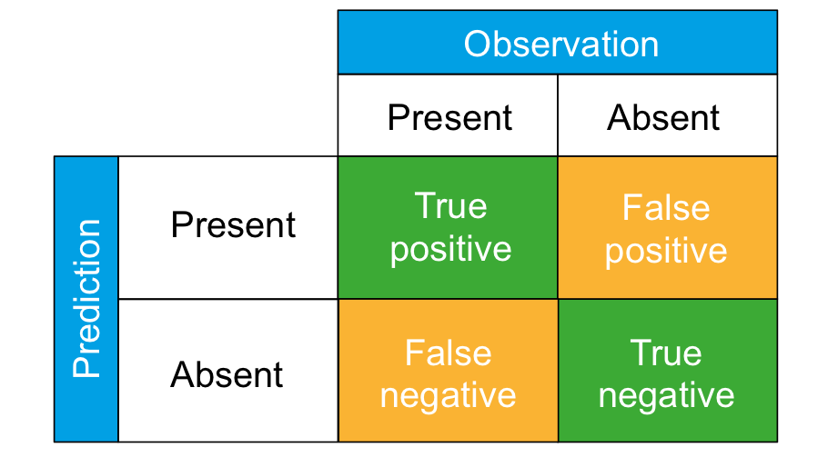

True positive rate is also called the *Sensitivity* and the true negative rate the *Specificity*.

The threshold chosen affect these two rates:

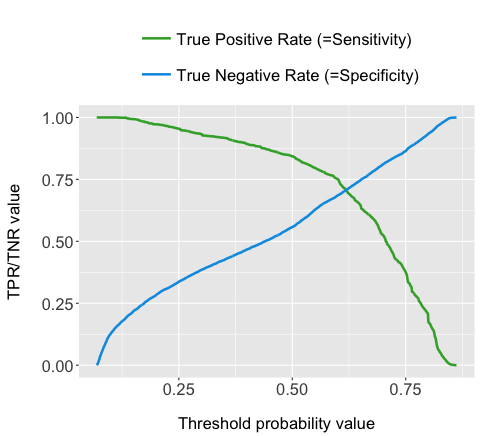

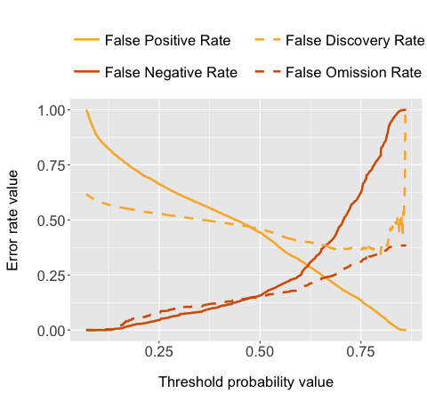

The most common evaluation statistic that avoids thresholding the data is AUC - the area under the receiver-operating characteristic (ROC) curve. ROC curves are generated by calculating sensitivity (true positive rate) and specificity (true negative rate) for many thresholds along the entire range of predicted probabilities. Then, (1-specificity) is plotted on the x-axis against sensitivity on the y axis. The area under this curve is called the AUC. The further the generated curve deviates from the 1:1 line towards the upper-left corner, the better the model predicts presence/absence of a species. If we would take a random presence and a random absence from our observations and make predictions, than AUC can be interpeted as the chance of assigning a higher predicted occurrence probability to the presence compared to the absence point. Typically, we regard AUC>0.7 as indicating fair predictions (Araujo et al. 2005).

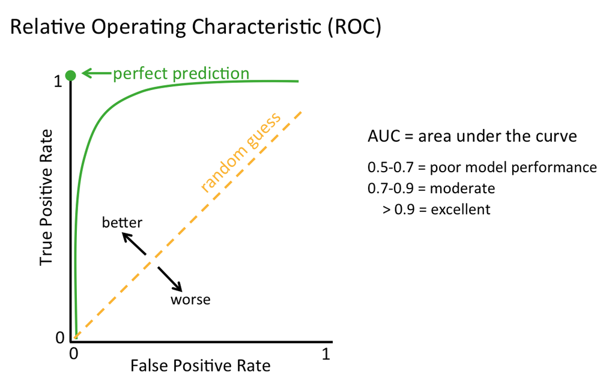

We will assess classification precision of the logistic models using ROC (Receiver Operating Characteristic Curve) and AUC (Area Under Curve) for one species (*Mauritia flexuosa*). The ROC curve shows the true positive rate (sensitivity) against the false positive rate (1 - specificity) at various threshold values at which the species may be considered present. The AUC is the area under the ROC curve.

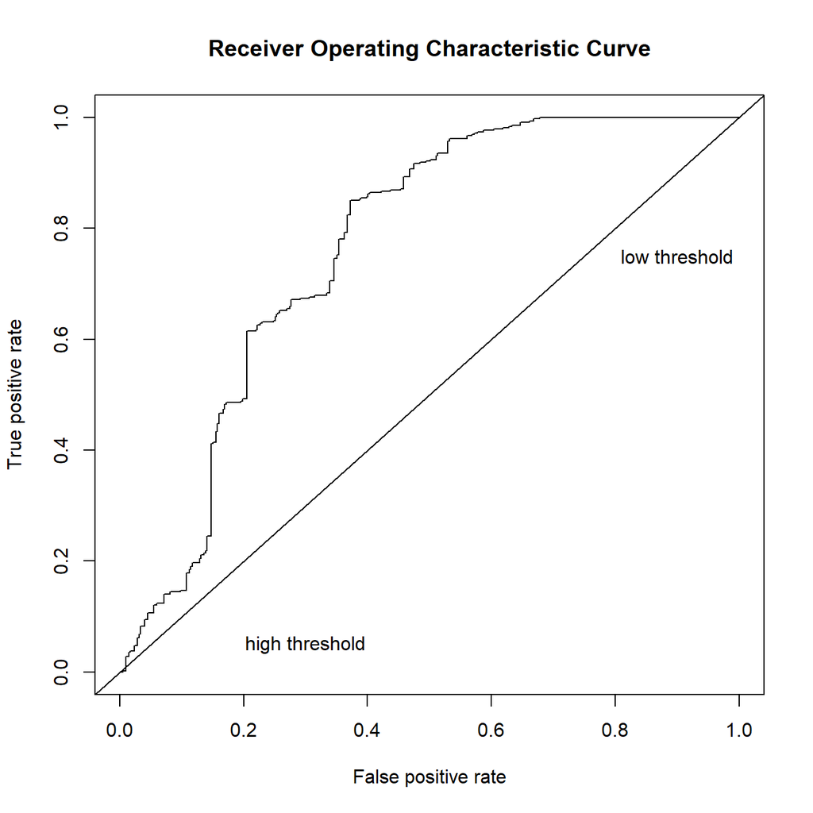

```r
p <- predict(logreg_mau_fle, newdata = mau_fle_abs, type = "response")
pr <- prediction(p, mau_fle_abs$present)

prf <- ROCR::performance(pr, measure = "tpr", x.measure = "fpr")
plot(prf, main = "Receiver Operating Characteristic Curve")
abline(a = 0, b = 1)
text(0.9, 0.75, "low threshold")
text(0.3, 0.05, "high threshold")
```

For the ROC, the curve should be located in the upper left of the figure which means that at intermediate threshold values the true positive rate is much higher than the false positive rate.

```r
auc <- ROCR::performance(pr, measure = "auc")
auc <- auc@y.values[[1]]
auc
```

```
## [1] 0.7653427
```

For the AUC, the value should be greater than 0.50 (i.e. a good model should be correct more than 50% of the time). The higher the AUC, the better the model is at predicting 0s as 0s and 1s as 1s.

We can also assess model performance using commonly used indices, such as R<sup>2</sup>, AIC, RMSE, LOGLOSS, and PCP.  
* The Root Mean Square Error (RMSE) is the square root of the mean squared residuals (prediction errors). Residuals are a measure of how far from the regression line data points are.  
* LOGLOSS evaluates how good or bad predicted probabilities are (high is bad, low is good).  
* PCP is percentage of correct predictions for models with binary outcomes.

```r
model_performance(logreg_geo_und,
                  metrics = c("AIC", "R2", "RMSE", "LOGLOSS", "PCP"))
```

```
## # Indices of model performance
##
## AIC     | Tjur's R2 |  RMSE | Log_loss |   PCP
## ----------------------------------------------
## 936.213 |     0.681 | 0.276 |    0.285 | 0.841
```

```r
model_performance(logreg_geo_pau,
                  metrics = c("AIC", "R2", "RMSE", "LOGLOSS", "PCP"))
```

```
## # Indices of model performance
##
## AIC     | Tjur's R2 |  RMSE | Log_loss |   PCP
## ----------------------------------------------
## 363.756 |     0.040 | 0.490 |    0.671 | 0.520
```

```r
model_performance(logreg_phy_ten,
                  metrics = c("AIC", "R2", "RMSE", "LOGLOSS", "PCP"))
```

```
## # Indices of model performance
##
## AIC    | Tjur's R2 |  RMSE | Log_loss |   PCP
## ---------------------------------------------
## 56.216 |     0.649 | 0.295 |    0.294 | 0.824
```

```r
model_performance(logreg_mau_fle,
                  metrics = c("AIC", "R2", "RMSE", "LOGLOSS", "PCP"))
```

```
## # Indices of model performance
##
## AIC     | Tjur's R2 |  RMSE | Log_loss |   PCP
## ----------------------------------------------
## 952.432 |     0.236 | 0.435 |    0.563 | 0.618
```

More details on the evaluation of the performance of SDMs [here](https://damariszurell.github.io/EEC-MGC/b4_SDM_eval.html).

# 6. Predict species distributions and compare to actual distributions

**Create new data for predictions**

```r
new_extent <- ext(-97, -35, -30, 17) # crop the raster layers to smaller extent

elev <- crop(elev, new_extent) # crop raster layers to smaller extent
elev <- aggregate(elev, fact = 4, fun = mean) # aggregate data
```

```
##
|---------|---------|---------|---------|
=========================================
```

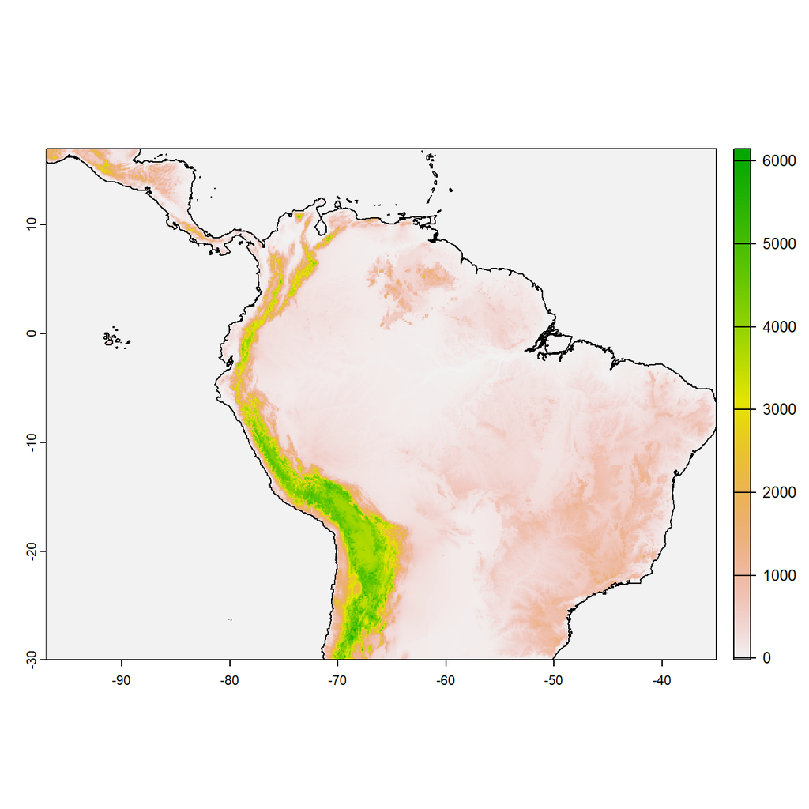

```r
plot(elev)
plot(st_geometry(americas), add=TRUE)
```

```r
bio1 <- crop(bio1, new_extent)
bio1 <- aggregate(bio1, fact = 4, fun = mean)
```

```
##
|---------|---------|---------|---------|
=========================================
```

```r
bio12 <- crop(bio12, new_extent)
bio12 <- aggregate(bio12, fact = 4, fun = mean)
```

```
##
|---------|---------|---------|---------|
=========================================
```

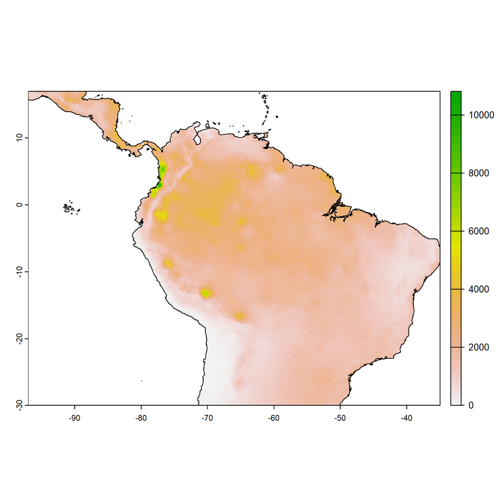

```r
plot(bio12)
plot(st_geometry(americas), add = TRUE)
```

**Predict presences of each species using our previously fitted species distribution models**

```r
new_data <- data.frame(elev = as.numeric(values(elev)),
                       bio1 = as.numeric(values(bio1)),
                       bio12 = as.numeric(values(bio12)))

# predict presences
geo_pau_predict <- predict(logreg_geo_pau, newdata = new_data,
                           type = "response")
geo_und_predict <- predict(logreg_geo_und, newdata = new_data,
                           type = "response")
phy_ten_predict <- predict(logreg_phy_ten, newdata = new_data,
                           type = "response")
mau_fle_predict <- predict(logreg_mau_fle, newdata = new_data,
                           type = "response")

par(mfrow = c(1, 1), mar = c(2, 2, 2, 2))

# create raster layers with SDM predictions
geo_pau_predict_rst <- rast(new_extent, nrows=nrow(elev), ncols=ncol(elev),
                            vals = geo_pau_predict)
geo_und_predict_rst <- rast(new_extent, nrows=nrow(elev), ncols=ncol(elev),
                            vals = geo_und_predict)
phy_ten_predict_rst <- rast(new_extent, nrows=nrow(elev), ncols=ncol(elev),
                            vals = phy_ten_predict)
mau_fle_predict_rst <- rast(new_extent, nrows=nrow(elev), ncols=ncol(elev),
                            vals = mau_fle_predict)
```

**Compare SDM predictions to actual species ranges**

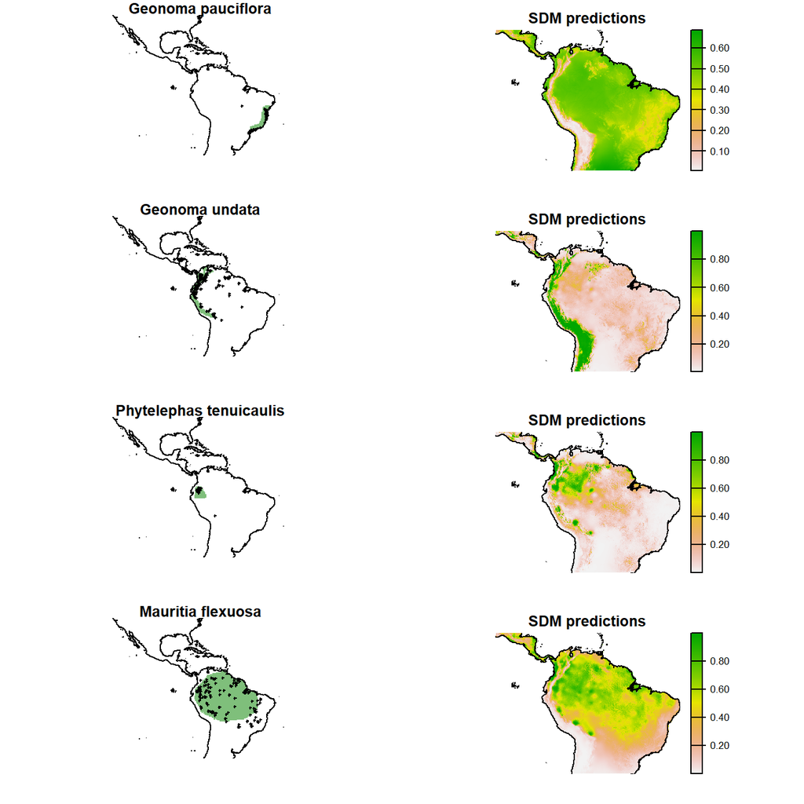

```r
par(mfrow = c(4, 2), mar = c(3, 1, 1, 1))

plot(st_geometry(grid),
     col=ifelse(grid$Geonoma.pauciflora==1,"#7fbf7b","white"),
     border=FALSE, main = "Geonoma pauciflora")
points(spec_occ$longitude[which(spec_occ$scrubbed_species_binomial == "Geonoma pauciflora")],
       spec_occ$latitude[which(spec_occ$scrubbed_species_binomial == "Geonoma pauciflora")],
       pch=3,cex=0.3)
plot(st_geometry(americas),add=TRUE)


plot(geo_pau_predict_rst, main="SDM predictions", axes=FALSE, box=FALSE)
plot(st_geometry(americas),add=TRUE)

plot(st_geometry(grid),
     col=ifelse(grid$Geonoma.undata==1,"#7fbf7b","white"),
     border=FALSE, main = "Geonoma undata")
plot(st_geometry(americas),add=TRUE)
points(spec_occ$longitude[which(spec_occ$scrubbed_species_binomial == "Geonoma undata")],
       spec_occ$latitude[which(spec_occ$scrubbed_species_binomial == "Geonoma undata")],
       pch=3,cex=0.3)

plot(geo_und_predict_rst,main="SDM predictions", axes=FALSE, box=FALSE)
plot(st_geometry(americas),add=TRUE)


plot(st_geometry(grid),
     col=ifelse(grid$Phytelephas.tenuicaulis==1,"#7fbf7b","white"),
     border=FALSE, main = "Phytelephas tenuicaulis")
points(spec_occ$longitude[which(spec_occ$scrubbed_species_binomial == "Phytelephas tenuicaulis")],
       spec_occ$latitude[which(spec_occ$scrubbed_species_binomial == "Phytelephas tenuicaulis")],
       pch=3,cex=0.3)
plot(st_geometry(americas),add=TRUE)

plot(phy_ten_predict_rst,main="SDM predictions", axes=FALSE, box=FALSE)
plot(st_geometry(americas),add=TRUE)

plot(st_geometry(grid),
     col=ifelse(grid$Mauritia.flexuosa==1,"#7fbf7b","white"),
     border=FALSE, main = "Mauritia flexuosa")
points(spec_occ$longitude[which(spec_occ$scrubbed_species_binomial == "Mauritia flexuosa")],
       spec_occ$latitude[which(spec_occ$scrubbed_species_binomial == "Mauritia flexuosa")],
       pch=3,cex=0.3)
plot(st_geometry(americas),add=TRUE)

plot(mau_fle_predict_rst,main="SDM predictions", axes=FALSE, box=FALSE)
plot(st_geometry(americas),add=TRUE)
```

For further information about geo-spatial analysis, consult tutorials available via [the Coding Club](https://ourcodingclub.github.io/2019/03/26/spatial.html) or [Geocomputation with R](https://geocompr.robinlovelace.net/read-write.html)

Some images from the evaluation of the performance of the models were extracted from [support.bccvl.org.au](https://support.bccvl.org.au/support/solutions/articles/6000127046-sdm-interpretation-of-model-outputs)

See also the site of [Damaris Zurell](https://damariszurell.github.io/EEC-MGC/b4_SDM_eval.html) for more content on the interpretation and evaluation of SDMs.